# Assignment 3

## Question 4

8.24 Surface roughness of pipe - page 390 a) Give the null and alternative hypotheses for testing whether the mean surface roughness of coated interior pipe, mu, differs from 2 micrometers.

```r
pipe = c(1.72, 2.50, 2.16, 2.13, 1.06, 2.24, 2.31, 2.03, 1.09, 1.40, 2.57, 2.64, 1.26, 2.05, 1.19, 2.13, 1.27, 1.51, 2.41, 1.95)
lengthPipe = length(pipe)
meanPipe = mean(pipe)
meanPipe
```

```
## [1] 1.881
```

## Question 5

8.28 Dissolved organic compound in lakes - page 392

1. Use a hypotheses test (at alpha = 0.10) to make an inference about whether the sample is representative of all Wisconsin lakes for the characteristic, dissolved organic compound. Calculating for t-stats below gives us a tcalc of -0.186. The tcalc being negative means the sample is not representative of all Wisconsin lakes.

```r
wisclakes = c(9.6, 4.5, 13.2, 4.1, 22.6, 2.7, 14.7, 3.5, 13.6, 19.8, 14.3, 56.9, 25.1, 18.4, 2.7, 4.2, 30.2, 10.3, 17.6, 2.4, 17.3, 38.8, 3.0, 5.8, 7.6)
meanDOC = mean(wisclakes)
sdDOC = sqrt(var(wisclakes))
lengthDOC = length(wisclakes)

tcalc = (meanDOC-15)/(sdDOC/sqrt(lengthDOC))
tcalc
```

```
## [1] -0.1866753
```

2. What is the likelihood that the test, part a, will detect a mean that differs from 15 grams/m^3 if, in fact, mu_0 = 14 grams/m^3?
   $$\bar{y}=\mu_0-t\frac{s}{sqrt(n)} \\
   \bar{y}=\mu_0+t\frac{s}{sqrt(n)} \\$$

$$\bar{y}=15-(-0.185)\frac{12.96}{sqrt(25)} = 15.48 \\
\bar{y}=15+(-0.185)\frac{12.96}{sqrt(25)} = 14.52 \\$$

## Question 6

8.44 Insecticides used in orchards - page 401

```r
orchards = read.csv("ORCHARD.csv")
orchards
```

| DAY | CONDITION | THION | OXON | RATIO |
| --- | --- | --- | --- | --- |
| 15 | FOG | 38.2 | 10.3 | 0.270 |
| 17 | FOG | 28.6 | 6.9 | 0.241 |
| 18 | FOG | 30.2 | 6.2 | 0.205 |
| 19 | FOG | 23.7 | 12.4 | 0.523 |
| 20 | FOG | 62.3 | NA | NA |
| 20 | CLEAR | 74.1 | 45.8 | 0.618 |
| 21 | FOG | 88.2 | 9.9 | 0.112 |
| 21 | CLEAR | 46.4 | 27.4 | 0.591 |
| 22 | FOG | 135.9 | 44.8 | 0.330 |
| 23 | FOG | 102.9 | 27.8 | 0.270 |

[output cut: 3 more lines]

```r
# Size of foggy data.
n1 = 8
# Size of cloudy/clear data.
n2 = 4

# Standard deviation of foggy data.
s1foggy = with(orchards, orchards[CONDITION=="FOG" & RATIO!="",])
s1 = 0.1186
sd(s1foggy$RATIO)
```

```
## [1] NA
```

```r
y1 = 0.2738

# Standard deviation of cloudy/clear data.
s2clear = with(orchards, orchards[CONDITION=="CLEAR" | CONDITION=="CLOUD",])
s2 = sd(s2clear$RATIO)
y2 = mean(s2clear$RATIO)

# Calculations for the formula for test statistics.
sp = ((n1-1)*s1^2+(n2-1)*s2^2)/(n1+n2-2)

tcalc = ((y1-y2)-0)/(sqrt(sp*((1/n1)+(1/n2))))
tcalc
```

```
## [1] -2.046307
```

## Question 7

8.84 Cooling methods for gas turbines - page 425.

Conduct a test (at alpha = 0.05) for equality of heat rate variances for traditional and aeroderivative augmented gas turbines. Use the result to make a statement about the validity of the inference derived in Exercise 8.33a.

```r
gasturbine = read.csv("GASTURBINE.csv")
gas_traditional = with(gasturbine, gasturbine[ENGINE=="Traditional",])
gas_aeroderiv = with(gasturbine, gasturbine[ENGINE=="Aeroderiv",])

x = rnorm(gas_traditional$HEATRATE, mean = mean(gas_traditional$HEATRATE, sd = sd(gas_traditional$HEATRATE)))
y = rnorm(gas_aeroderiv$HEATRATE, mean = mean(gas_aeroderiv$HEATRATE), sd = sd(gas_aeroderiv$HEATRATE))

var.test(x, y, conf.level = 0.95)
```

```
##
##  F test to compare two variances
##
## data:  x and y
## F = 6.0265e-08, num df = 38, denom df = 6, p-value < 2.2e-16
## alternative hypothesis: true ratio of variances is not equal to 1
## 95 percent confidence interval:
##  1.200293e-08 1.665324e-07
## sample estimates:
## ratio of variances
##         6.0265e-08
```

Conduct a test (at alpha = 0.05) for equality of heat rate variances for advanced and aeroderivative augmented gas turbines. Use the result to make a statement about the validity of the inference derived in Exercise 8.33b.

```r
gas_augmented = with(gasturbine, gasturbine[ENGINE=="Advanced",])
z = rnorm(gas_augmented, mean = mean(gas_augmented$HEATRATE), sd = sd(gas_augmented$HEATRATE))

var.test(y, z, conf.level = 0.95)
```

```
##
##  F test to compare two variances
##
## data:  y and z
## F = 40.22, num df = 6, denom df = 10, p-value = 3.916e-06
## alternative hypothesis: true ratio of variances is not equal to 1
## 95 percent confidence interval:
##    9.876937 219.655448
## sample estimates:
## ratio of variances
##           40.22018
```

## Question 8

8.99 Mongolian desert ants - page 438.

1. Set up H0 and H1 for determining whether the variances are the same.

```r
gobiants = read.csv("GOBIANTS.csv")
dry_ants = with(gobiants, gobiants[Region!="Gobi Desert",])
dry_ants
```

|  | Site | Region | Rain | Temp | PlantCov | AntSpecies | Diversity |
| --- | --- | --- | --- | --- | --- | --- | --- |
| 1 | 1 | Dry Steppe | 196 | 5.7 | 40 | 3 | 0.89 |
| 2 | 2 | Dry Steppe | 196 | 5.7 | 52 | 3 | 0.83 |
| 3 | 3 | Dry Steppe | 179 | 7.0 | 40 | 52 | 1.31 |
| 4 | 4 | Dry Steppe | 197 | 8.0 | 43 | 7 | 1.48 |
| 5 | 5 | Dry Steppe | 149 | 8.5 | 27 | 5 | 0.97 |

```r
gobi_ants = with(gobiants, gobiants[Region=="Gobi Desert",])
gobi_ants
```

|  | Site | Region | Rain | Temp | PlantCov | AntSpecies | Diversity |
| --- | --- | --- | --- | --- | --- | --- | --- |
| 6 | 6 | Gobi Desert | 112 | 10.7 | 30 | 49 | 0.46 |
| 7 | 7 | Gobi Desert | 125 | 11.4 | 16 | 5 | 1.23 |
| 8 | 8 | Gobi Desert | 99 | 10.9 | 30 | 4 | NA |
| 9 | 9 | Gobi Desert | 125 | 11.4 | 56 | 4 | 0.76 |
| 10 | 10 | Gobi Desert | 84 | 11.4 | 22 | 5 | 1.26 |
| 11 | 11 | Gobi Desert | 115 | 11.4 | 14 | 4 | 0.69 |

```r
x = rnorm(dry_ants$AntSpecies, mean = mean(dry_ants$AntSpecies, sd = sd(dry_ants$AntSpecies)))
y = rnorm(gobi_ants$AntSpecies, mean = mean(gobi_ants$AntSpecies), sd = sd(gobi_ants$AntSpecies))

var.test(x, y, 0.95)
```

```
##
##  F test to compare two variances
##
## data:  x and y
## F = 0.0068892, num df = 4, denom df = 5, p-value = 0.0002614
## alternative hypothesis: true ratio of variances is not equal to 0.95
## 95 percent confidence interval:
##  0.0008858686 0.0612876119
## sample estimates:
## ratio of variances
##        0.006544696
```

2. Use the data in the GOBIANTS file to find the test statistic for the test.

```r
tcalc =(x-mean(gobiants$AntSpecies))/((sd(gobiants$AntSpecies))/(length(gobiants)))
tcalc
```

```
## [1] 0.8953068 0.8486194 0.7824155 0.9745813 0.1806064
```

3. Give the rejection region for the test if alpha = 0.05. Rejection region is outside the 0.00089 and 0.061.
4. Find the approximate p-value of the test. p-value = 0.0002614.
5. Make the appropriate conclusion in the words of the problem. Basics of var.test with p-value, CI with acceptance and rejection region, and degrees of freedom.
6. What conditions are required for the test results be valid? Variances be equal.

## Question 9

8.104 Real-time scheduling with robots - page 439.

```r
thruput = read.csv("THRUPUT.csv")

# Null hypotheses.
h0 = mean(thruput$HUMAN)-mean(thruput$AUTO)
n = 8

tcalc = (-32.6-0)/(35/sqrt(n))
tcalc
```

```
## [1] -2.634478
```

## Question 10

Using and making adjustments to myboot function.

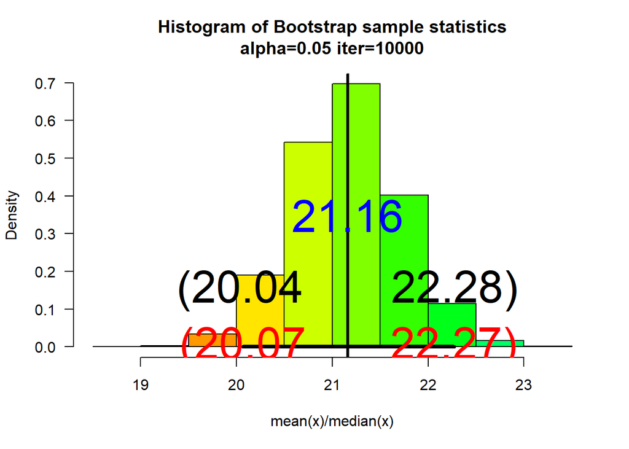

```
## $ci
##     2.5%    97.5%
## 20.06700 22.26845
##
## $fun
## [1] "mean"
##
## $x
##  [1] 23.195 20.399 19.898 19.865 30.014 18.821 21.232 18.313 23.574 21.047
## [11] 21.535 21.336 17.695 18.497 14.274 14.664 22.593 18.963 25.515 25.019
## [21] 22.053 22.871 23.006 23.829 19.038 21.735 21.461 21.659 21.703 21.049
##
## $tcalc
## [1] 0.002416818
```

```r
set.seed(35); sam<-round(rnorm(30,mean=20,sd=3),3)
MATH4753NGUY0132::ASS4myboot(10000,x=sam,alpha=0.05,xlab="mean(x)/median(x)")
```